# Lecture 7: Uplift Modeling

Who Will Change Behavior Because of This Campaign?

## Every model serves a marketing decision

Win customers

CMO: “Which channels and touchpoints are actually bringing customers in?”

- L01A/B testingDid it work?
- L03Marketing mix modelingHow much?
- L06Multi-touch attributionHow much?

Set the offer

Head of pricing: “What should we charge, and which features matter?”

- L02Price elasticityHow much?
- L09Conjoint analysisWhat do they want?

The marketing decisionStart from what the business is asking

Keep customers

Head of retention: “Who is leaving, when, and who should get the save offer?”

- L04Survival analysisWhat next?
- L05Markov chainsWhat next?
- L07Uplift modeling · todayDid it work?

Value customers

CFO: “What is a customer worth to us?”

- L08Customer lifetime valueWhat next?

Plan ahead

Operations: “What will next quarter look like?”

- L10Demand forecastingWhat next?

**Question type:**Did it work? causal effectHow much? how much X moves YWhat do they want? preferencesWhat next? prediction

## Motivating Problem

**Tip**

**Setting:** A firm runs an A/B test (a randomized experiment) to estimate heterogeneous treatment effects: how the campaign’s effect differs from one kind of customer to another. You have a $4 retention campaign. Not every at-risk customer will renew because of it. Some would renew anyway. Some will react negatively. **Who should you actually target?**

**Learning Objectives**

- Compute ATE and explain what it does and doesn’t tell you
- Apply the T-learner to predict individual treatment effects
- Calculate the profit-maximizing targeting threshold
- Identify sleeping dogs (negative-effect customers)
- Interpret a Qini coefficient

## Typology of Treatment Response

You need this

| Segment | Without campaign | With campaign | Decision |
| --- | --- | --- | --- |
| Sure Things | Would convert | Would convert | Don’t spend $4 |
| Persuadables | Won’t convert | **Will convert** | **Target** |
| Lost Causes | Won’t convert | Won’t convert | Don’t spend $4 |
| Sleeping Dogs | Would convert | **Won’t convert** | **Never target** |

**Warning**

**Policy implication:** The optimal targeting rule excludes customers whose uplift is positive but **unprofitable** ($0 < \hat{\tau}(x) < c/v$) and sleeping dogs ($\hat{\tau}(x) < 0$). Sure things need no rule — their uplift is ≈ 0, so the threshold excludes them automatically. Both errors are distinct and costly.

## Average Treatment Effect (ATE)

You need this

From a randomized experiment:

$$\text{ATE} = E[Y(1)] - E[Y(0)] = \bar{Y}_{\text{treated}} - \bar{Y}_{\text{control}}$$

The ATE is a population-average estimand and is uninformative about heterogeneity. A customer with $\tau(x) = +0.30$ and one with $\tau(x) = -0.10$ average to $+0.10$.

**Tip**

The quantity of interest is the **conditional** effect $\tau(x) = E[Y(1) - Y(0) \mid X = x]$: the average uplift among customers with features $x$. The ATE is its average over everyone, $\text{ATE} = E[\tau(X)]$.

## T-Learner (Two-Model Approach)

You need this

Train one model per treatment arm ($x$ = the customer’s features; a hat marks an estimate):

$$\hat{\tau}(x) = \hat{\mu}_1(x) - \hat{\mu}_0(x)$$

**Step 1:** Train $\hat{\mu}_1$ on treated customers to predict $P(\text{convert} \mid \text{treated}, x)$

**Step 2:** Train $\hat{\mu}_0$ on control customers to predict $P(\text{convert} \mid \text{control}, x)$

**Step 3:** For any customer:  
Subtract → $\hat{\tau}(x)$

If $\hat{\tau}(x) > 0$: this customer benefits  
If $\hat{\tau}(x) < 0$: sleeping dog

## Targeting Threshold

You need this

Expected profit from targeting a customer with uplift $\hat{\tau}(x)$:

$$\text{Profit}(\hat{\tau}) = \hat{\tau}(x) \cdot v - c$$

where $v$ = conversion value, $c$ = campaign cost.

**Target if and only if:**

$$\hat{\tau}(x) > \frac{c}{v}$$

**Example:** $c = \$4$, $v = \$30/\text{month} \to$ threshold $= 4/30 = 0.133$

Customer with $\hat{\tau} = 0.10$: expected profit $= 0.10(30) - 4 = -\$1.00$ → don’t target

## Qini Coefficient

You need this

Measures how well the model ranks customers by uplift:

Contact customers in $\hat{\tau}$ order, highest first, and count the extra conversions you get as you go down the list. That running count is the **Qini curve**.

$$\text{Qini} = \frac{\text{area between model curve and random line}}{\text{area between perfect curve and random line}}$$

- Qini = 0: no better than random · Qini = 1: perfect · Qini < 0: worse than random
- It is **not** the share of Persuadables the model finds

⚠️ **Always say which split.** The same model scores ~20× higher in-sample than held out. Report held-out; compare models on the same held-out customers.

```python
from sklift.metrics import qini_auc_score
qini = qini_auc_score(
    y_true,
    uplift_scores,
    treatment
)
```

## Qini Curve: Held-Out vs In-Sample

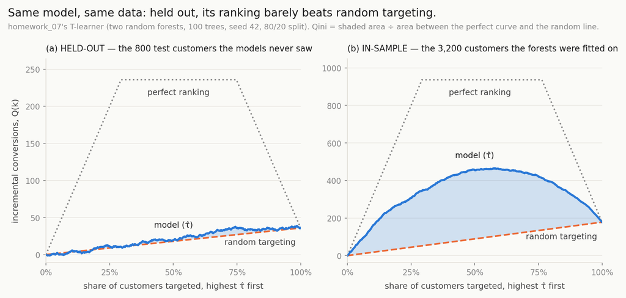

Report the **held-out** number: it is the only one that says how the ranking does on new customers.

## Optional: How the Qini Curve Is Computed

Background: why it works, not on quizzes

`sklift` computes this for you. This slide shows what it is doing.

Rank by $\hat{\tau}$, highest first. Treated vs. control = the experiment’s own coin flip; $\hat{\tau}$ only sorts, so each top-$k$ slice is a mini-experiment. Incremental conversions in the top $k$:

$$Q(k) = Y_T(k) - Y_C(k)\,\frac{N_T(k)}{N_C(k)}$$

Control conversions are scaled up to the size of the treated group, then subtracted.

Full walk-through: lecture notes, Section 1.4, Part C (“Who moves Q”).

## Sleeping Dogs: Business Reality

Customers with $\hat{\tau}(x) < 0$: the campaign **causes them not to convert**.

**Why this happens:**

- “We’ll miss you” emails remind happy customers they’re on autopilot — and prompt re-evaluation
- Discounts signal the product isn’t worth full price to discount-sensitive customers
- Frequency overload → unsubscribes

**Warning**

At 8% sleeping dogs in a 50,000-customer campaign:  
You cause 4,000 unnecessary cancellations. This is real, measurable harm.

## Practice: work in pairs (1 of 2)

Answer each one, then mark **Sure** or **Unsure** as you would on the quiz.

**1. True or false?** A propensity model ranks customers by how likely they are to renew. Sending the campaign to its top-ranked customers reaches the Persuadables.

**2.** Among customers with features $x$: 30% are Sure Things, 20% Persuadables, 5% Sleeping Dogs and 45% Lost Causes. What is the uplift $\tau(x)$?

A. 0.50 B. 0.25 C. 0.20 D. 0.15

**3.** Campaign cost $c = \$5$, conversion value $v = \$40$. A customer has $\hat{\tau}(x) = 0.10$. What is the expected incremental profit from contacting them?

A. $+\$4.00$ B. $+\$1.00$ C. $-\$1.00$ D. $-\$0.025$

Answers in the lecture notes, under “Slide Practice Answers” (numbered to match these slides).

## Practice: work in pairs (2 of 2)

**4. True or false?** Two customers both have $\hat{\tau}(x) \approx 0$. One has $\hat{\mu}_0 = 0.85$ and the other $\hat{\mu}_0 = 0.05$. The first looks like a Sure Thing and the second like a Lost Cause.

**5.** A T-learner’s Qini is 0.45 on the customers it was trained on and 0.09 on held-out customers from the same A/B test. Which number do you report?

A. 0.45: it uses more customers, so it is more precise  
B. 0.09: it is the only one that says how the ranking does on new customers  
C. Their average, 0.27  
D. Neither: a held-out Qini needs a second experiment

**6. True or false?** A feature near the top of the importances of *both* $\hat{\mu}_1$ and $\hat{\mu}_0$ is a strong driver of who responds to the campaign.

Answers in the lecture notes, under “Slide Practice Answers” (numbered to match these slides).

## Checkpoint

1. ATE = 0.108. Threshold = 0.12. Is the average customer profitable to target?
2. A customer has $\hat{\tau}(x) = 0.05$, $c = \$4$, $v = \$25$. Target them?
3. The Qini coefficient = 0.00. What does this mean in plain language?
4. Why does T-learner require random assignment for unbiased CATE estimates?
5. Campaign reaches 10,000 customers. 12% are sleeping dogs. Campaign cost = $4 each. What is the direct cost of targeting sleeping dogs?

Answers in the lecture notes, under “Slide Checkpoint Answers” (numbered to match this slide).